# CUNY Data 621 HW3 Logiistical Regression

Raphael Nash

# Introduction

This assignement we will do a logistical regression to predict crime giving an input dataset. A training and evaluation dataset have been provided.

To accomplish this I am going to use the following libraries: 1. ggplot2 2. reshape2 3. coreplot 4. forecast 5. dplyr 6. Deducer

# Data Exploration

Summary Statistics:

```
       zn             indus             chas              nox               rm             age              dis              rad             tax           ptratio         lstat
 Min.   :  0.00   Min.   : 0.460   Min.   :0.00000   Min.   :0.3890   Min.   :3.863   Min.   :  2.90   Min.   : 1.130   Min.   : 1.00   Min.   :187.0   Min.   :12.6   Min.   : 1.730
 1st Qu.:  0.00   1st Qu.: 5.145   1st Qu.:0.00000   1st Qu.:0.4480   1st Qu.:5.887   1st Qu.: 43.88   1st Qu.: 2.101   1st Qu.: 4.00   1st Qu.:281.0   1st Qu.:16.9   1st Qu.: 7.043
 Median :  0.00   Median : 9.690   Median :0.00000   Median :0.5380   Median :6.210   Median : 77.15   Median : 3.191   Median : 5.00   Median :334.5   Median :18.9   Median :11.350
 Mean   : 11.58   Mean   :11.105   Mean   :0.07082   Mean   :0.5543   Mean   :6.291   Mean   : 68.37   Mean   : 3.796   Mean   : 9.53   Mean   :409.5   Mean   :18.4   Mean   :12.631
 3rd Qu.: 16.25   3rd Qu.:18.100   3rd Qu.:0.00000   3rd Qu.:0.6240   3rd Qu.:6.630   3rd Qu.: 94.10   3rd Qu.: 5.215   3rd Qu.:24.00   3rd Qu.:666.0   3rd Qu.:20.2   3rd Qu.:16.930
 Max.   :100.00   Max.   :27.740   Max.   :1.00000   Max.   :0.8710   Max.   :8.780   Max.   :100.00   Max.   :12.127   Max.   :24.00   Max.   :711.0   Max.   :22.0   Max.   :37.970
      medv           target
 Min.   : 5.00   Min.   :0.0000
 1st Qu.:17.02   1st Qu.:0.0000
 Median :21.20   Median :0.0000
 Mean   :22.59   Mean   :0.4914
 3rd Qu.:25.00   3rd Qu.:1.0000
 Max.   :50.00   Max.   :1.0000
```

Box Plot of data

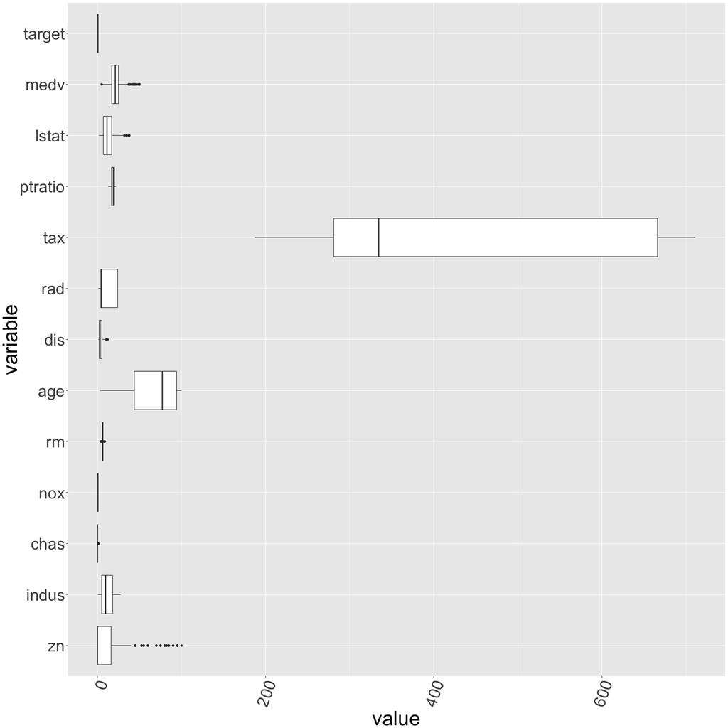

Correlation Plot of Data:

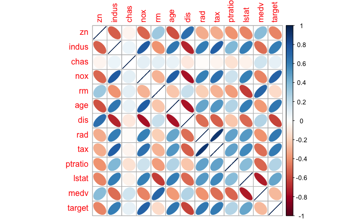

Correlation Matrix:

```
                 zn       indus        chas         nox          rm         age         dis         rad         tax    ptratio       lstat       medv      target
zn       1.00000000 -0.53826643 -0.04016203 -0.51704518  0.31981410 -0.57258054  0.66012434 -0.31548119 -0.31928408 -0.3910357 -0.43299252  0.3767171 -0.43168176
indus   -0.53826643  1.00000000  0.06118317  0.75963008 -0.39271181  0.63958182 -0.70361886  0.60062839  0.73222922  0.3946898  0.60711023 -0.4961743  0.60485074
chas    -0.04016203  0.06118317  1.00000000  0.09745577  0.09050979  0.07888366 -0.09657711 -0.01590037 -0.04676476 -0.1286606 -0.05142322  0.1615653  0.08004187
nox     -0.51704518  0.75963008  0.09745577  1.00000000 -0.29548972  0.73512782 -0.76888404  0.59582984  0.65387804  0.1762687  0.59624264 -0.4301227  0.72610622
rm       0.31981410 -0.39271181  0.09050979 -0.29548972  1.00000000 -0.23281251  0.19901584 -0.20844570 -0.29693430 -0.3603471 -0.63202445  0.7053368 -0.15255334
age     -0.57258054  0.63958182  0.07888366  0.73512782 -0.23281251  1.00000000 -0.75089759  0.46031430  0.51212452  0.2554479  0.60562001 -0.3781560  0.63010625
dis      0.66012434 -0.70361886 -0.09657711 -0.76888404  0.19901584 -0.75089759  1.00000000 -0.49499193 -0.53425464 -0.2333394 -0.50752800  0.2566948 -0.61867312
rad     -0.31548119  0.60062839 -0.01590037  0.59582984 -0.20844570  0.46031430 -0.49499193  1.00000000  0.90646323  0.4714516  0.50310125 -0.3976683  0.62810492
tax     -0.31928408  0.73222922 -0.04676476  0.65387804 -0.29693430  0.51212452 -0.53425464  0.90646323  1.00000000  0.4744223  0.56418864 -0.4900329  0.61111331
ptratio -0.39103573  0.39468980 -0.12866058  0.17626871 -0.36034706  0.25544785 -0.23333940  0.47145160  0.47442229  1.0000000  0.37735605 -0.5159153  0.25084892
lstat   -0.43299252  0.60711023 -0.05142322  0.59624264 -0.63202445  0.60562001 -0.50752800  0.50310125  0.56418864  0.3773560  1.00000000 -0.7358008  0.46912702
medv     0.37671713 -0.49617432  0.16156528 -0.43012267  0.70533679 -0.37815605  0.25669476 -0.39766826 -0.49003287 -0.5159153 -0.73580078  1.0000000 -0.27055071
target  -0.43168176  0.60485074  0.08004187  0.72610622 -0.15255334  0.63010625 -0.61867312  0.62810492  0.61111331  0.2508489  0.46912702 -0.2705507  1.00000000
```

# Transformations

| lambda | variable |
| --- | --- |
| 0.07538486 | zn |
| -0.08779326 | indus |
| 0.47220206 | chas |
| -0.99992425 | nox |
| 0.28832202 | rm |
| 1.99992425 | age |
| -0.61031032 | dis |
| -0.33539473 | rad |
| -0.99992425 | tax |
| 1.99992425 | ptratio |

[output cut: 2 more lines]

# Build Models

I will bild a model starting with all the variables are removing the least signifigant variables until the AIC starts increaseing

Summary of model will all varirables (model1):

```
Call:
glm(formula = target ~ ., family = binomial, data = crime_transformed_df)

Deviance Residuals:
    Min       1Q   Median       3Q      Max
-2.0857  -0.1090  -0.0005   0.1040   3.5539

Coefficients:
              Estimate Std. Error z value Pr(>|z|)
(Intercept)  1.045e+02  1.629e+01   6.413 1.43e-10 ***
zn          -5.404e-01  5.688e-01  -0.950 0.342083
indus       -6.930e+00  8.486e+00  -0.817 0.414123
chas         6.668e-01  7.567e-01   0.881 0.378228
nox         -7.454e+01  1.166e+01  -6.391 1.65e-10 ***
rm          -9.119e-01  7.382e-01  -1.235 0.216730
age          3.586e-04  1.097e-04   3.268 0.001083 **
dis         -1.443e+01  3.136e+00  -4.601 4.20e-06 ***
rad         -1.800e+01  4.312e+00  -4.174 2.99e-05 ***
tax          3.080e+02  4.097e+02   0.752 0.452159
ptratio      1.327e-02  3.867e-03   3.430 0.000603 ***
lstat        2.156e-02  5.465e-02   0.395 0.693184
medv         2.588e-01  7.437e-02   3.480 0.000502 ***
---
Signif. codes:  0 ‘***’ 0.001 ‘**’ 0.01 ‘*’ 0.05 ‘.’ 0.1 ‘ ’ 1

(Dispersion parameter for binomial family taken to be 1)

    Null deviance: 645.88  on 465  degrees of freedom
Residual deviance: 187.92  on 453  degrees of freedom
AIC: 213.92

Number of Fisher Scoring iterations: 8
```

```r
model2 <- glm(target~nox+ age+dis+ rad+ptratio+medv  , data =crime_transformed_df, family=binomial )
summary(model2)
```

```
Call:
glm(formula = target ~ nox + age + dis + rad + ptratio + medv,
    family = binomial, data = crime_transformed_df)

Deviance Residuals:
    Min       1Q   Median       3Q      Max
-1.9517  -0.1563  -0.0018   0.1220   3.3766

Coefficients:
              Estimate Std. Error z value Pr(>|z|)
(Intercept)  9.114e+01  1.339e+01   6.806 1.00e-11 ***
nox         -7.209e+01  1.062e+01  -6.786 1.15e-11 ***
age          3.151e-04  8.489e-05   3.711 0.000206 ***
dis         -1.242e+01  2.720e+00  -4.566 4.98e-06 ***
rad         -1.438e+01  2.840e+00  -5.064 4.11e-07 ***
ptratio      1.189e-02  2.991e-03   3.977 6.99e-05 ***
medv         1.609e-01  3.647e-02   4.411 1.03e-05 ***
---
Signif. codes:  0 ‘***’ 0.001 ‘**’ 0.01 ‘*’ 0.05 ‘.’ 0.1 ‘ ’ 1

(Dispersion parameter for binomial family taken to be 1)

    Null deviance: 645.88  on 465  degrees of freedom
Residual deviance: 196.11  on 459  degrees of freedom
AIC: 210.11

Number of Fisher Scoring iterations: 7
```

The least signifigant variable of all the variables left is age, so I will drop that variable and create a model with the remaining variables.  
Here is the summary of that model:

```
Call:
glm(formula = target ~ nox + dis + rad + ptratio + medv, family = binomial,
    data = crime_transformed_df)

Deviance Residuals:
     Min        1Q    Median        3Q       Max
-2.28102  -0.20082  -0.00392   0.11758   3.01871

Coefficients:
              Estimate Std. Error z value Pr(>|z|)
(Intercept)  93.454841  12.836413   7.280 3.33e-13 ***
nox         -73.167876  10.047631  -7.282 3.29e-13 ***
dis          -8.839983   2.407010  -3.673 0.000240 ***
rad         -13.009411   2.664509  -4.882 1.05e-06 ***
ptratio       0.009869   0.002781   3.548 0.000388 ***
medv          0.116046   0.030818   3.765 0.000166 ***
---
Signif. codes:  0 ‘***’ 0.001 ‘**’ 0.01 ‘*’ 0.05 ‘.’ 0.1 ‘ ’ 1

(Dispersion parameter for binomial family taken to be 1)

    Null deviance: 645.88  on 465  degrees of freedom
Residual deviance: 211.10  on 460  degrees of freedom
AIC: 223.1

Number of Fisher Scoring iterations: 7
```

Since AIC started to go up, I am going to stop removing variables.

# Select Models:

I am going to select the model based on area under the ROC curve (A/K/A AUC) and AIC.

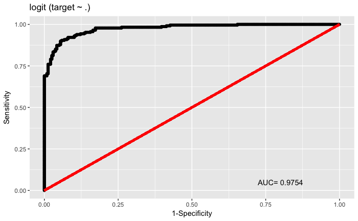

The AIC for model1 is 213.9225599

Model2 Variables in Model 2: nox + age + dis + rad + ptratio + medv

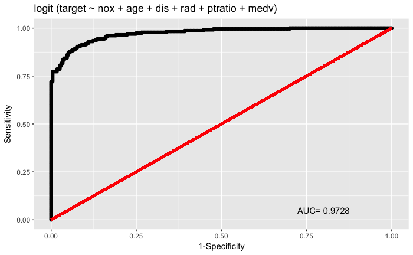

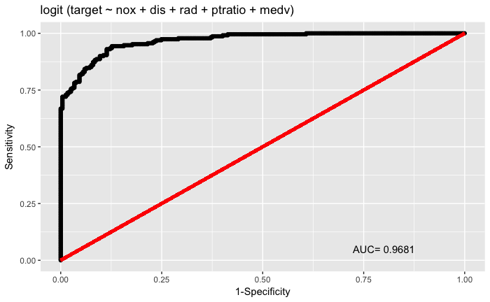

The AIC for model3 is 223.1014769

# Make Predications

|  | prediction | zn | indus | chas | nox | rm | age | dis | rad | tax | ptratio | lstat | medv |
| --- | --- | --- | --- | --- | --- | --- | --- | --- | --- | --- | --- | --- | --- |
| 1 | 0 | 0 | 7.07 | 0 | 0.469 | 7.185 | 61.1 | 4.9671 | 2 | 242 | 17.8 | 4.03 | 34.7 |
| 2 | 0 | 0 | 8.14 | 0 | 0.538 | 6.096 | 84.5 | 4.4619 | 4 | 307 | 21.0 | 10.26 | 18.2 |
| 3 | 0 | 0 | 8.14 | 0 | 0.538 | 6.495 | 94.4 | 4.4547 | 4 | 307 | 21.0 | 12.80 | 18.4 |
| 4 | 0 | 0 | 8.14 | 0 | 0.538 | 5.950 | 82.0 | 3.9900 | 4 | 307 | 21.0 | 27.71 | 13.2 |
| 5 | 0 | 0 | 5.96 | 0 | 0.499 | 5.850 | 41.5 | 3.9342 | 5 | 279 | 19.2 | 8.77 | 21.0 |
| 6 | 0 | 25 | 5.13 | 0 | 0.453 | 5.741 | 66.2 | 7.2254 | 8 | 284 | 19.7 | 13.15 | 18.7 |
| 7 | 0 | 25 | 5.13 | 0 | 0.453 | 5.966 | 93.4 | 6.8185 | 8 | 284 | 19.7 | 14.44 | 16.0 |
| 8 | 0 | 0 | 4.49 | 0 | 0.449 | 6.630 | 56.1 | 4.4377 | 3 | 247 | 18.5 | 6.53 | 26.6 |
| 9 | 0 | 0 | 4.49 | 0 | 0.449 | 6.121 | 56.8 | 3.7476 | 3 | 247 | 18.5 | 8.44 | 22.2 |
| 10 | 0 | 0 | 2.89 | 0 | 0.445 | 6.163 | 69.6 | 3.4952 | 2 | 276 | 18.0 | 11.34 | 21.4 |

[output cut: 30 more lines]

# Appendix (R Code)

## Setup

library(ggplot2)

library(reshape2)

library(corrplot)

library(forecast)

library(dplyr)

library(Deducer)

crime_df <- read.csv(“crime-training-data.csv”)

## Data Exploration

summary(crime_df )

ggplot(data = melt(crime_df), aes(x=variable, y=value)) + geom_boxplot() + coord_flip() + theme(text = element_text(size=40), axis.text.x = element_text(angle=70, hjust=1))

M <- cor((crime_df)) corrplot(M, method = “ellipse”)

pairs(crime_df, col=crime_df$target)

## Transformations

calculate_labbdas <- function(df){

df <- df[,1:ncol(df)]

l1 <- numeric(ncol(df))

for (i in 1:ncol(df)){

```
l1[i] <- BoxCox.lambda(df[,i])
```

}

return(data.frame(l1, colnames(df)))

}

box_cox_lambdas <- calculate_labbdas( dplyr::select(crime_df, -target))

colnames(box_cox_lambdas) <- c(“lambda”, “variable”)

box_cox_lambdas

crime_transformed_df <- crime_df

crime_transformed_df$zn <- crime_transformed_df$zn ^ (filter(box_cox_lambdas, variable==“zn”)$lambda)

crime_transformed_df$indus <- crime_transformed_df$indus ^ (filter(box_cox_lambdas, variable==“indus”)$lambda)

crime_transformed_df$chas <- crime_transformed_df$chas ^ (filter(box_cox_lambdas, variable==“chas”)$lambda)

crime_transformed_df$nox <- crime_transformed_df$nox ^ (filter(box_cox_lambdas, variable==“nox”)$lambda)

crime_transformed_df$nox <- crime_transformed_df$nox ^ (filter(box_cox_lambdas, variable==“rm”)$lambda)

crime_transformed_df$age <- crime_transformed_df$age ^ (filter(box_cox_lambdas, variable==“age”)$lambda)

crime_transformed_df$dis <- crime_transformed_df$dis ^ (filter(box_cox_lambdas, variable==“dis”)$lambda)

crime_transformed_df$rad <- crime_transformed_df$rad ^ (filter(box_cox_lambdas, variable==“rad”)$lambda)

crime_transformed_df$tax <- crime_transformed_df$tax ^ (filter(box_cox_lambdas, variable==“tax”)$lambda)

crime_transformed_df$ptratio <- crime_transformed_df$ptratio ^ (filter(box_cox_lambdas, variable==“ptratio”)$lambda)

## Build Models

model1 <- glm(target~., data =crime_transformed_df, family=binomial )

summary(model1)

model2 <- glm(target~nox+ age+dis+ rad+ptratio+medv , data =crime_transformed_df, family=binomial )

summary(model2)

model3 <- glm(target~nox+dis+ rad+ptratio+medv , , data =crime_transformed_df, family=binomial )

summary(model3)

## Select Models:

rocplot(model1)

rocplot(model2)

rocplot(model3)

## Make Predications

crime_eval_df <- read.csv(“crime-evaluation-data.csv”)

crime_eval_transformed_df <- crime_eval_df

crime_eval_transformed_df$zn <- crime_eval_transformed_df$zn ^ (filter(box_cox_lambdas, variable==“zn”)$lambda)

crime_eval_transformed_df$indus <- crime_eval_transformed_df$indus ^ (filter(box_cox_lambdas, variable==“indus”)$lambda)

crime_eval_transformed_df$chas <- crime_eval_transformed_df$chas ^ (filter(box_cox_lambdas, variable==“chas”)$lambda)

crime_eval_transformed_df$nox <- crime_eval_transformed_df$nox ^ (filter(box_cox_lambdas, variable==“nox”)$lambda)

crime_eval_transformed_df$nox <- crime_eval_transformed_df$nox ^ (filter(box_cox_lambdas, variable==“rm”)$lambda)

crime_eval_transformed_df$age <- crime_eval_transformed_df$age ^ (filter(box_cox_lambdas, variable==“age”)$lambda)

crime_eval_transformed_df$dis <- crime_eval_transformed_df$dis ^ (filter(box_cox_lambdas, variable==“dis”)$lambda)

crime_eval_transformed_df$rad <- crime_eval_transformed_df$rad ^ (filter(box_cox_lambdas, variable==“rad”)$lambda)

crime_eval_transformed_df$tax <- crime_eval_transformed_df$tax ^ (filter(box_cox_lambdas, variable==“tax”)$lambda)

crime_eval_transformed_df$ptratio <- crime_eval_transformed_df$ptratio ^ (filter(box_cox_lambdas, variable==“ptratio”)$lambda)

probs <- predict(model2,crime_eval_df)

prediction <- ifelse ( probs > .5 ,1,0)

cbind(prediction, crime_eval_df)